# Praca domowa 2

Maciej Andrzejewski

## Dane

Dane wykorzystane w Pracy domowej 2 opisują wycenę nieruchmości. Każda obserwacja jest pewną nieruchmością, która posiada informacje takie jak powierzchnia, liczba pokoi, liczba łazienek i wiele więcj. Opis wszystkich kolumn w pliku `README.md`.

## Zadanie 1

Jak wygląda rozkład ceny nieruchomości w poszczególnych kodach pocztowych na przestrzeni lat? Rozważamy kody pocztowe, które mają więcej niż 280 posiadłości.

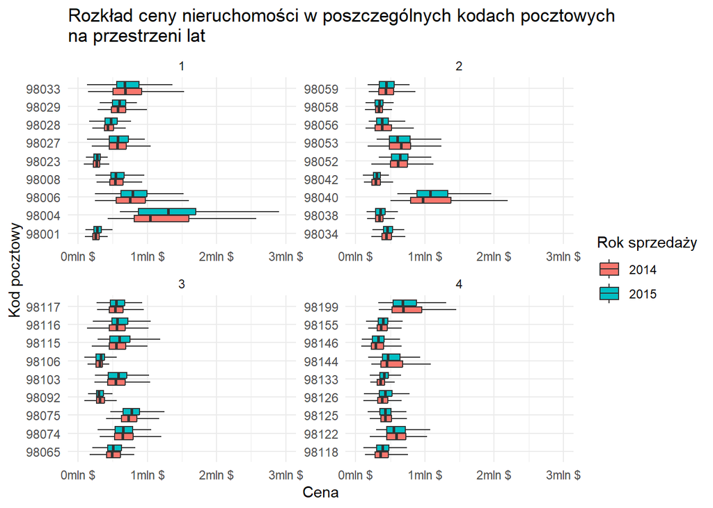

```r
x1 <- df %>% group_by(zipcode) %>%
  filter(n() > 280) %>%
  ungroup() %>%
  mutate(year = substr(date,1,4))

zips <- sort(unique(x1$zipcode))

x1 <- x1 %>% mutate(group = case_when(zipcode < zips[10] ~ 1,
                                      zipcode < zips[19] ~ 2,
                                      zipcode < zips[28] ~ 3,
                                      TRUE ~ 4))

ggplot(x1, aes(x = as.factor(zipcode), y = price, fill = year)) +
  geom_boxplot(outlier.shape = NA) +
  scale_y_continuous(limits = c(0,3000000), labels = scales::label_number(scale = 1e-6, suffix = "mln $")) +
  labs(
    title = "Rozkład ceny nieruchomości w poszczególnych kodach pocztowych\nna przestrzeni lat",
    fill = "Rok sprzedaży",
    y = "Cena",
    x = "Kod pocztowy"
  ) + coord_flip()  +
  theme_minimal() + facet_wrap(~group, scales = "free")
```

**Komentarz:** W większości przypadków ceny w 2015 roku są wyższe, niż w roku 2014

## Zadanie 2

Czy jest różnica w rozkładzie ceny nierchomości od powierzchni mieszkalnej uwzględniając podział na nieruchomości z piwnicą i bez?

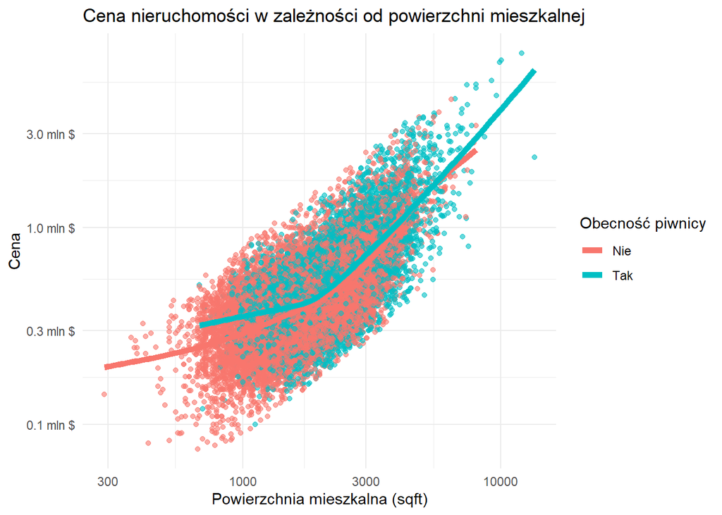

```r
df %>% mutate(has_basement = ifelse(sqft_basement == 0, "Nie", "Tak")) %>%
  ggplot(aes(x = sqft_living, y = price, color = has_basement, c(1,2))) +
  geom_point(alpha = 0.6) +
  geom_smooth(se = FALSE, linewidth = 2) +
  labs(
    title = "Cena nieruchomości w zależności od powierzchni mieszkalnej",
    x = "Powierzchnia mieszkalna (sqft)",
    y = "Cena",
    color = "Obecność piwnicy"
  ) + scale_y_log10(labels = scales::label_number(scale = 1e-6, suffix = " mln $")) +
  scale_x_log10() + theme_minimal()
```

**Komentarz:** Im większa powierzchnia mieszkalna, tym wyższa cena nieruchomości. Dodatkowo, przy porównywalnym metrażu mieszkania z piwnicą zazwyczaj są droższe od analogicznych bez piwnicy.

## Zadanie 3

Jaka jest zależność pomiędzy jakością wykończenia nieruchomości a liczbą pięter?

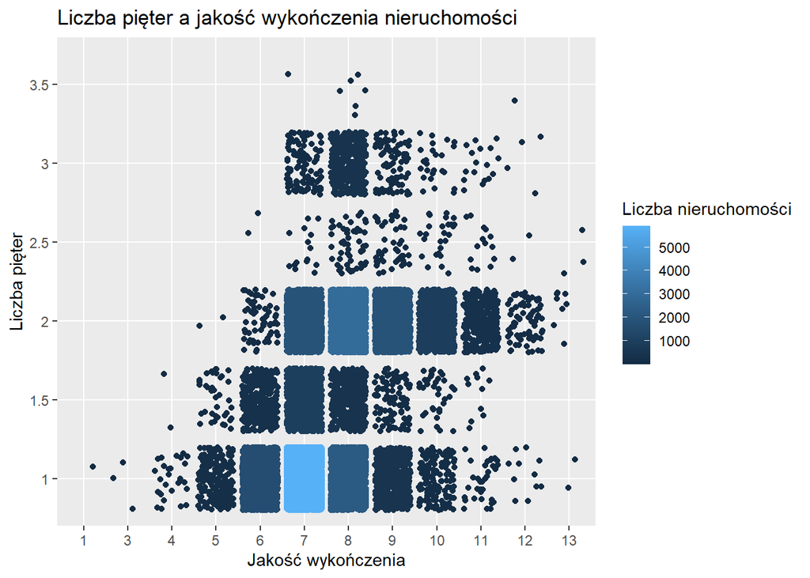

```r
  df %>% group_by(grade, floors) %>% mutate(count=n()) %>% ungroup() %>%
  ggplot(aes(as.factor(grade), as.factor(floors), color = count)) +
  geom_jitter() + labs(title = "Liczba pięter a jakość wykończenia nieruchomości",
                       x = "Jakość wykończenia",
                       y = "Liczba pięter",
                       color = "Liczba nieruchomości")
```

**Komentarz:** Najwięcej nieruchomości jest jakości wykończenia 7 i 8 - zarówno jednopiętrowe, jak i te z większą liczbą pięter. W przypadku liczby pięter większej lub równej 2 częściej występują też wyższe jakości wykończenia (9, 10, 11).

## Zadanie 4

Jaka jest zależność między powierzchnią mieszkalną nieruchomości a powierzchnią gruntu w podziale na liczbę sypialni?

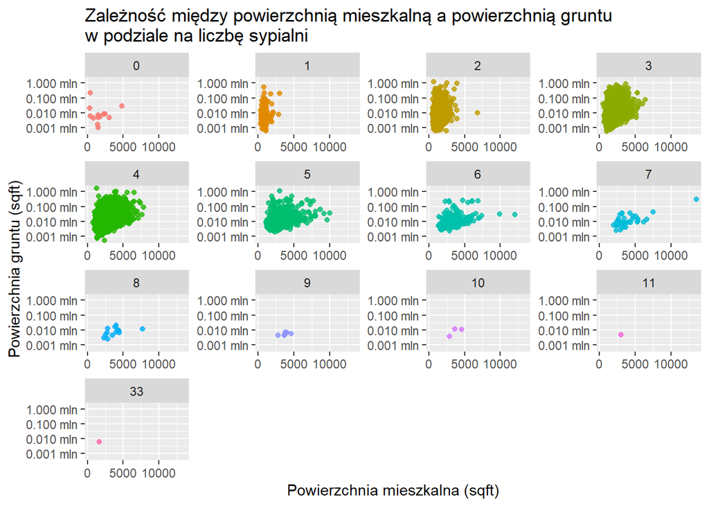

```r
  ggplot(df, aes(x = sqft_living, y = sqft_lot, color = factor(bedrooms))) +
    geom_point(alpha = 0.8) +
    labs(
      title = "Zależność między powierzchnią mieszkalną a powierzchnią gruntu\nw podziale na liczbę sypialni",
      x = "Powierzchnia mieszkalna (sqft)",
      y = "Powierzchnia gruntu (sqft)",
      color = "Liczba sypialni") +
     scale_y_log10(labels = scales::label_number(scale = 1e-6, suffix = " mln"))+
     theme(legend.position = "none")  +
     facet_wrap(~bedrooms, axes = "all")
```

**Komentarz:** Brak korelacji - nie ma zależności między powierzchnią mieszkalną nieruchomości a powierzchnią gruntu.

## Zadanie 5

Rozważmy tylko nieruchomości, które miały remont. W której dekadzie było najwięcej przeprowadzonych remontów? Czy w poszczególnych dekadach jest porównywalny procent nieruchmości dla każdej wartości miary jakości i wykończenia nieruchomości?

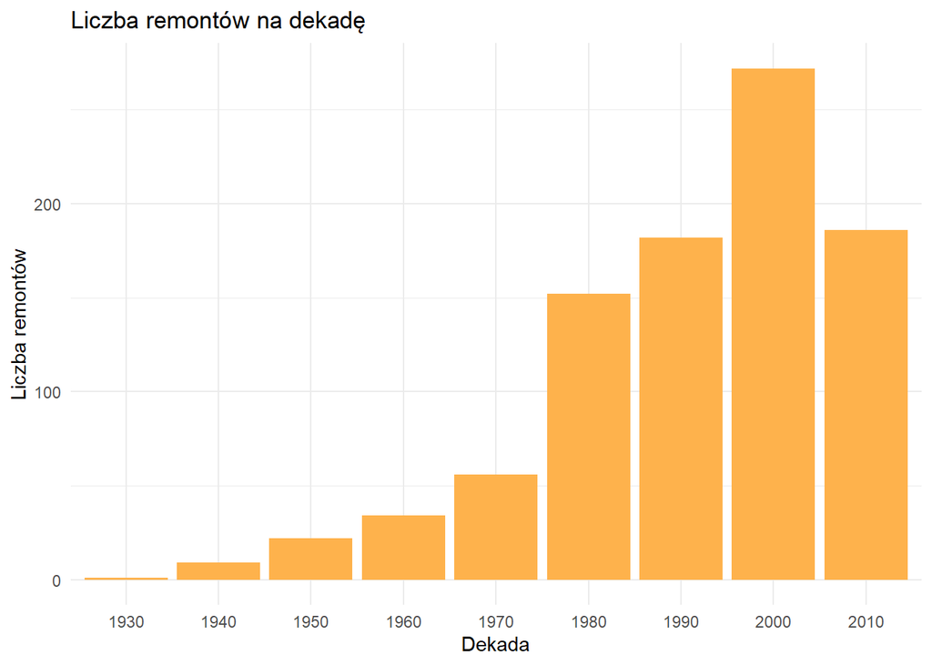

```r
df %>% filter(yr_renovated > 0) %>% mutate(decade = floor(yr_renovated/10)*10) %>%
  ggplot(aes(as.factor(decade))) + geom_bar(fill = "#feb24c") +
  labs(title = "Liczba remontów na dekadę",
       x = "Dekada",
       y = "Liczba remontów") +
  theme_minimal()
```

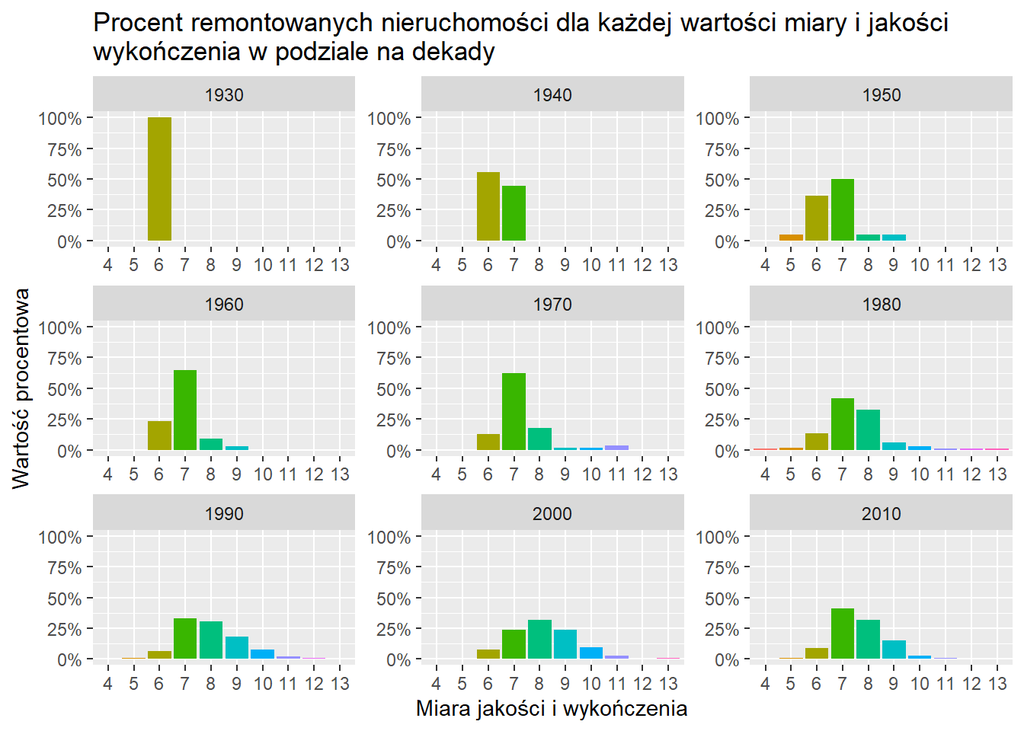

```r
df %>% filter(yr_renovated > 0) %>%
  mutate(decade = floor(yr_renovated/10)*10) %>%
  group_by(decade) %>%
  mutate(decade_sum = n()) %>%
  group_by(decade, grade) %>%
  reframe(percentage = n()/decade_sum, .groups = "keep") %>%
  distinct() %>%
  ggplot(aes(as.factor(grade), percentage, fill = as.factor(grade))) +
  geom_col() + theme(legend.position = "none") +
  labs(title = "Procent remontowanych nieruchomości dla każdej wartości miary i jakości\nwykończenia w podziale na dekady",
       x = "Miara jakości i wykończenia", y = "Wartość procentowa") +
  scale_y_continuous(labels = scales::label_percent()) +
  facet_wrap(~decade, axes = "all")
```

**Komentarz:** Najwięcej remontów przeprowadzono w latach dwutysięcznych. W żadnej z dekad nie ma porównywalnego procenta wyremontowanych nieruchomości pod względem miary jakości i wykończenia.

## Zadanie 6

Jak prezentuje się wartość minimalna, średnia i maksymalna ceny nieruchmości w podziele na rok budowy nieruchomości.

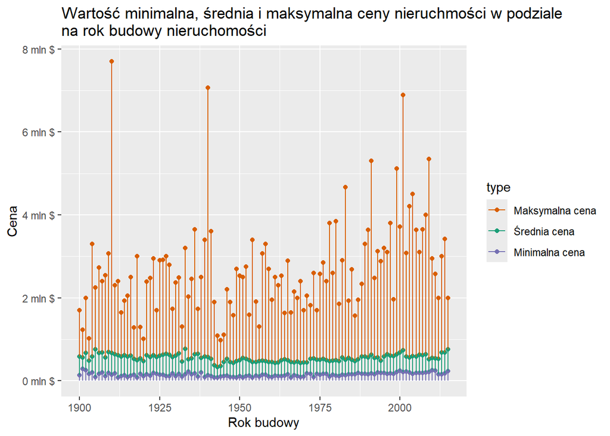

```r
stats <- df %>%
  group_by(yr_built) %>%
  summarise(
    min_cena = min(price),
    srednia_cena = mean(price),
    max_cena = max(price)
  )
stats_long <- stats %>%
  tidyr::pivot_longer(cols = c(max_cena, srednia_cena, min_cena),
               names_to = "type",
               values_to = "cena") %>%
  mutate(type = factor(type, levels = c("max_cena", "srednia_cena", "min_cena")))

ggplot(stats_long, aes(yr_built, cena, color = type)) +
  geom_point()+
  geom_segment(aes(xend = yr_built, y=0, yend = cena)) +
  scale_color_manual(values = c("#d95f02", "#1b9e77","#7570b3"),
                     labels = c("max_cena" = "Maksymalna cena",
                                "srednia_cena" = "Średnia cena",
                                "min_cena" = "Minimalna cena")) +
  labs(title = "Wartość minimalna, średnia i maksymalna ceny nieruchmości w podziale\nna rok budowy nieruchomości",
       x = "Rok budowy",
       y = "Cena") +
  scale_y_continuous(labels = scales::label_number(scale = 1e-6, suffix = " mln $"))
```

**Komentarz:** Minimalna i średnia cena nieruchomości na przestrzeni lat pozostaje na podobnym poziomie, natomiast maksymalna cena nieruchomości zmienia się znacząco zależnie od roku.